# Research guide: CBSA-year frame

925 CBSAs (2023 delineation) x 25 years, 2000-2024: 23,125 rows, 422 variables

Research Guide

## Boolean

boolean

1

`qcew_fgov_imputed`

1 = suppressed county cell, imputed as state total minus disclosed counties, allocated by population: federal

| ROWS | DISTINCT | ZERO |
| --- | --- | --- |
| 23,125 | 2 (0.0%) | 23,117 (100.0%) |

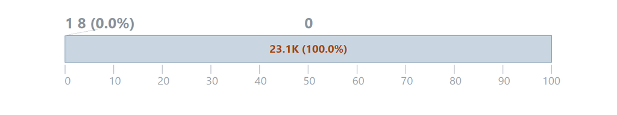

**PREVIEW**:

```
0 · 1
```

**CATEGORY LABELS**:

| 0 | 1 |
| --- | --- |

boolean · indicator

1

`pf_interp`

1 = foundation values interpolated (2016-18)

| ROWS | DISTINCT |
| --- | --- |
| 23,125 | 2 (0.0%) |

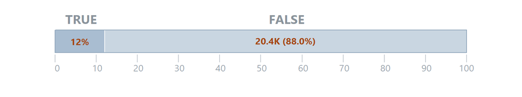

**PREVIEW**:

```
FALSE · TRUE
```

**CATEGORY LABELS**:

| FALSE | TRUE |
| --- | --- |

boolean

1

`bmf_src_monthly`

1 = 2023-24 counts from the NCCS monthly BMF

| ROWS | DISTINCT | ZERO |
| --- | --- | --- |
| 23,125 | 2 (0.0%) | 21,275 (92.0%) |

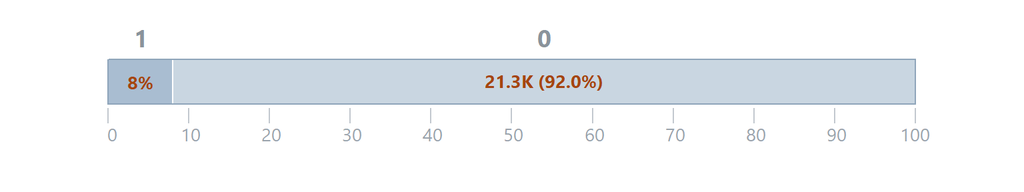

**PREVIEW**:

```
0 · 1
```

**CATEGORY LABELS**:

| 0 | 1 |
| --- | --- |

boolean

1

`entry_src_monthly`

1 = 2022-24 entries from the Dec 2024 monthly BMF (survivors only)

| ROWS | DISTINCT | ZERO |
| --- | --- | --- |
| 23,125 | 2 (0.0%) | 20,350 (88.0%) |

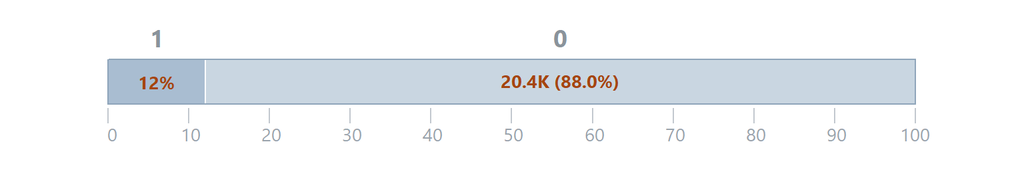

**PREVIEW**:

```
0 · 1
```

**CATEGORY LABELS**:

| 0 | 1 |
| --- | --- |

boolean

1

`rel_2000_noblack`

1 = 2000 file (historically Black bodies largely missing)

| ROWS | DISTINCT | MISSING/NA | ZERO |
| --- | --- | --- | --- |
| 23,125 | 3 (0.0%) | 20,350 (88.0%) | 1,850 (8.0%) |

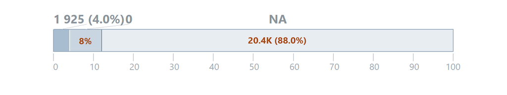

**PREVIEW**:

```
0 · 1
```

**CATEGORY LABELS**:

| 0 | 1 |
| --- | --- |

boolean

1

`socap_interp2000`

1 = 2000 interpolated from 1997 and 2005

| ROWS | DISTINCT | MISSING/NA | ZERO |
| --- | --- | --- | --- |
| 23,125 | 3 (0.0%) | 19,449 (84.1%) | 2,759 (11.9%) |

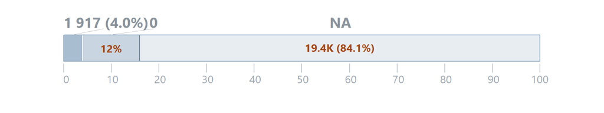

**PREVIEW**:

```
0 · 1
```

**CATEGORY LABELS**:

| 0 | 1 |
| --- | --- |

boolean

1

`patents_truncated`

1 = application year 2021+ (grant lag truncates counts)

| ROWS | DISTINCT | MISSING/NA | ZERO |
| --- | --- | --- | --- |
| 23,125 | 3 (0.0%) | 1,406 (6.1%) | 18,432 (79.7%) |

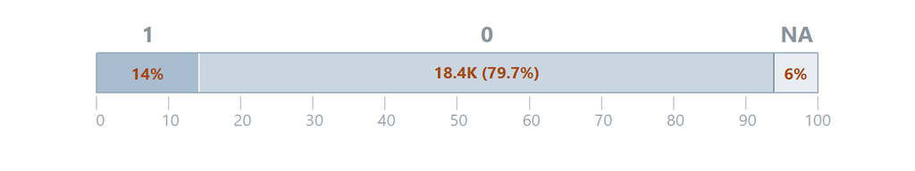

**PREVIEW**:

```
0 · 1
```

**CATEGORY LABELS**:

| 0 | 1 |
| --- | --- |

boolean

1

`bls_delin_flag`

1 = MSA code absent from the 2023 delineation or its county set changed

| ROWS | DISTINCT | MISSING/NA | ZERO |
| --- | --- | --- | --- |
| 23,125 | 3 (0.0%) | 19,448 (84.1%) | 3,605 (15.6%) |

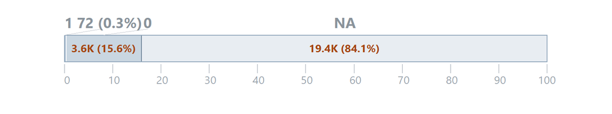

**PREVIEW**:

```
0 · 1
```

**CATEGORY LABELS**:

| 0 | 1 |
| --- | --- |

boolean · indicator

Share 25+ with BA+ (observed flag)

`pct_ba_obs`

Share 25+ with BA+. Observed flag: TRUE where the base value was observed that year, FALSE where it was filled.

| ROWS | DISTINCT |
| --- | --- |
| 23,125 | 2 (0.0%) |

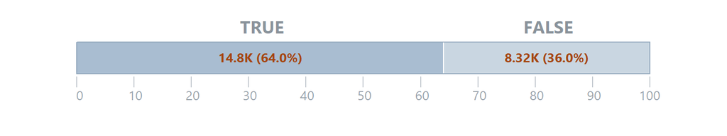

**PREVIEW**:

```
TRUE · FALSE
```

**CATEGORY LABELS**:

| FALSE | TRUE |
| --- | --- |

boolean · indicator

Foreign-born share (observed flag)

`pct_foreign_born_obs`

Foreign-born share. Observed flag: TRUE where the base value was observed that year, FALSE where it was filled. Identical to `pct_ba_obs` in this frame.

| ROWS | DISTINCT |
| --- | --- |
| 23,125 | 2 (0.0%) |

**PREVIEW**:

```
TRUE · FALSE
```

**CATEGORY LABELS**:

| FALSE | TRUE |
| --- | --- |

boolean · indicator

Household income Gini index (observed flag)

`gini_obs`

Household income Gini index. Observed flag: TRUE where the base value was observed that year, FALSE where it was filled.

| ROWS | DISTINCT |
| --- | --- |
| 23,125 | 2 (0.0%) |

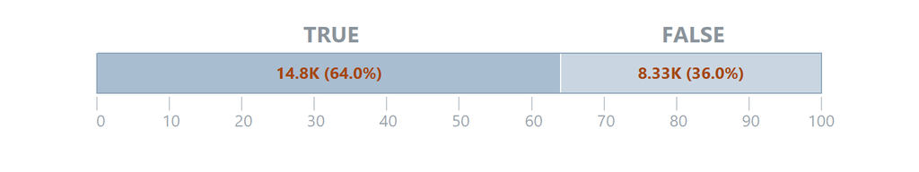

**PREVIEW**:

```
TRUE · FALSE
```

**CATEGORY LABELS**:

| FALSE | TRUE |
| --- | --- |

boolean · indicator

Presidential votes / population 18+ (observed flag)

`turnout_obs`

Presidential votes / population 18+. Observed flag: TRUE where the base value was observed that year, FALSE where it was filled.

| ROWS | DISTINCT |
| --- | --- |
| 23,125 | 2 (0.0%) |

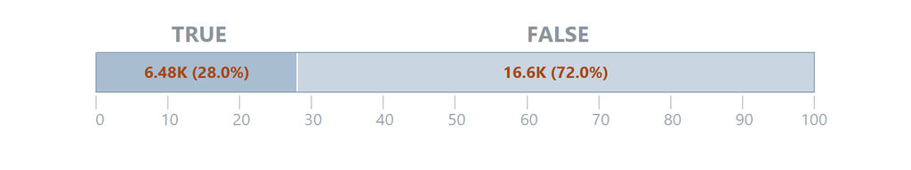

**PREVIEW**:

```
FALSE · TRUE
```

**CATEGORY LABELS**:

| FALSE | TRUE |
| --- | --- |

boolean · indicator

(votes_dem - votes_rep) / votes_total (observed flag)

`dem_margin_obs`

(votes_dem - votes_rep) / votes_total. Observed flag: TRUE where the base value was observed that year, FALSE where it was filled. Identical to `turnout_obs` in this frame.

| ROWS | DISTINCT |
| --- | --- |
| 23,125 | 2 (0.0%) |

**PREVIEW**:

```
FALSE · TRUE
```

**CATEGORY LABELS**:

| FALSE | TRUE |
| --- | --- |

boolean · indicator

Itemized charitable contributions, $ (observed flag)

`contrib_total_obs`

Itemized charitable contributions, $ (= a19700). Observed flag: TRUE where the base value was observed that year, FALSE where it was filled.

| ROWS | DISTINCT |
| --- | --- |
| 23,125 | 2 (0.0%) |

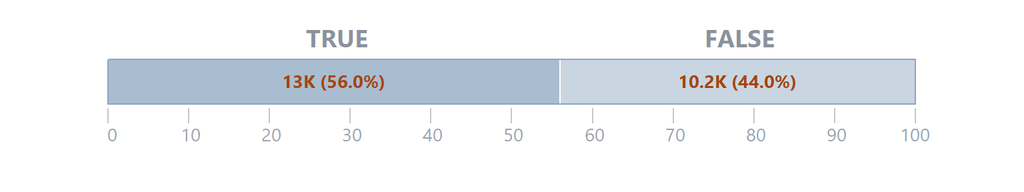

**PREVIEW**:

```
TRUE · FALSE
```

**CATEGORY LABELS**:

| FALSE | TRUE |
| --- | --- |

boolean · indicator

Itemized contributions per tax return (observed flag)

`contrib_per_return_obs`

Itemized contributions per tax return. Observed flag: TRUE where the base value was observed that year, FALSE where it was filled. Identical to `contrib_total_obs` in this frame.

| ROWS | DISTINCT |
| --- | --- |
| 23,125 | 2 (0.0%) |

**PREVIEW**:

```
TRUE · FALSE
```

**CATEGORY LABELS**:

| FALSE | TRUE |
| --- | --- |

boolean · indicator

Itemized contributions / AGI (observed flag)

`contrib_share_agi_obs`

Itemized contributions / AGI. Observed flag: TRUE where the base value was observed that year, FALSE where it was filled. Identical to `contrib_total_obs` in this frame.

| ROWS | DISTINCT |
| --- | --- |
| 23,125 | 2 (0.0%) |

**PREVIEW**:

```
TRUE · FALSE
```

**CATEGORY LABELS**:

| FALSE | TRUE |
| --- | --- |

boolean · indicator

HHI of adherent shares across religious bodies (observed flag)

`rel_hhi_obs`

HHI of adherent shares across religious bodies (0-1; higher = more concentrated). Observed flag: TRUE where the base value was observed that year, FALSE where it was filled.

| ROWS | DISTINCT |
| --- | --- |
| 23,125 | 2 (0.0%) |

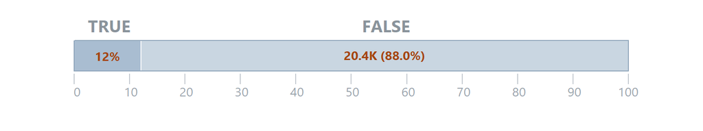

**PREVIEW**:

```
FALSE · TRUE
```

**CATEGORY LABELS**:

| FALSE | TRUE |
| --- | --- |

boolean · indicator

Religious adherents / population (observed flag)

`pct_adherent_obs`

Religious adherents / population. Observed flag: TRUE where the base value was observed that year, FALSE where it was filled. Identical to `rel_hhi_obs` in this frame.

| ROWS | DISTINCT |
| --- | --- |
| 23,125 | 2 (0.0%) |

**PREVIEW**:

```
FALSE · TRUE
```

**CATEGORY LABELS**:

| FALSE | TRUE |
| --- | --- |

boolean · indicator

Catholic adherents / all adherents (observed flag)

`pct_catholic_obs`

Catholic adherents / all adherents. Observed flag: TRUE where the base value was observed that year, FALSE where it was filled. Identical to `rel_hhi_obs` in this frame.

| ROWS | DISTINCT |
| --- | --- |
| 23,125 | 2 (0.0%) |

**PREVIEW**:

```
FALSE · TRUE
```

**CATEGORY LABELS**:

| FALSE | TRUE |
| --- | --- |

boolean · indicator

adherents (observed flag)

`rel_adh_obs`

adherents (count). Observed flag: TRUE where the base value was observed that year, FALSE where it was filled. Identical to `rel_hhi_obs` in this frame.

| ROWS | DISTINCT |
| --- | --- |
| 23,125 | 2 (0.0%) |

**PREVIEW**:

```
FALSE · TRUE
```

**CATEGORY LABELS**:

| FALSE | TRUE |
| --- | --- |

boolean · indicator

congregations (observed flag)

`rel_cng_obs`

congregations (count). Observed flag: TRUE where the base value was observed that year, FALSE where it was filled. Identical to `rel_hhi_obs` in this frame.

| ROWS | DISTINCT |
| --- | --- |
| 23,125 | 2 (0.0%) |

**PREVIEW**:

```
FALSE · TRUE
```

**CATEGORY LABELS**:

| FALSE | TRUE |
| --- | --- |

boolean · indicator

Catholic adherents (observed flag)

`rel_cath_adh_obs`

Catholic adherents (count). Observed flag: TRUE where the base value was observed that year, FALSE where it was filled. Identical to `rel_hhi_obs` in this frame.

| ROWS | DISTINCT |
| --- | --- |
| 23,125 | 2 (0.0%) |

**PREVIEW**:

```
FALSE · TRUE
```

**CATEGORY LABELS**:

| FALSE | TRUE |
| --- | --- |

boolean · indicator

association establishments (observed flag)

`socap_assn_n_obs`

association establishments (sum of 10 categories; CBP). Observed flag: TRUE where the base value was observed that year, FALSE where it was filled.

| ROWS | DISTINCT |
| --- | --- |
| 23,125 | 2 (0.0%) |

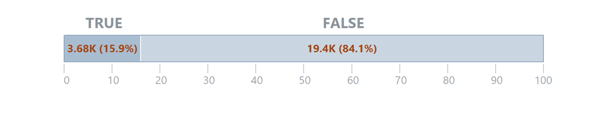

**PREVIEW**:

```
FALSE · TRUE
```

**CATEGORY LABELS**:

| FALSE | TRUE |
| --- | --- |

boolean · indicator

Census mail response rate (observed flag)

`socap_respn_obs`

Census mail response rate. Observed flag: TRUE where the base value was observed that year, FALSE where it was filled. Identical to `socap_assn_n_obs` in this frame.

| ROWS | DISTINCT |
| --- | --- |
| 23,125 | 2 (0.0%) |

**PREVIEW**:

```
FALSE · TRUE
```

**CATEGORY LABELS**:

| FALSE | TRUE |
| --- | --- |

boolean · indicator

published Rupasingha index (observed flag)

`socap_sk_obs`

published Rupasingha index (contains nccs = nonprofit density and pvote; validation / kitchen only). Observed flag: TRUE where the base value was observed that year, FALSE where it was filled. Identical to `socap_assn_n_obs` in this frame.

| ROWS | DISTINCT |
| --- | --- |
| 23,125 | 2 (0.0%) |

**PREVIEW**:

```
FALSE · TRUE
```

**CATEGORY LABELS**:

| FALSE | TRUE |
| --- | --- |

boolean · indicator

PC1 of log assn rate and respn, re-estimated per wave without nccs ... (observed flag)

`socap_sk2_obs`

PC1 of log assn rate and respn, re-estimated per wave without nccs and pvote. Observed flag: TRUE where the base value was observed that year, FALSE where it was filled. Identical to `socap_assn_n_obs` in this frame.

| ROWS | DISTINCT |
| --- | --- |
| 23,125 | 2 (0.0%) |

**PREVIEW**:

```
FALSE · TRUE
```

**CATEGORY LABELS**:

| FALSE | TRUE |
| --- | --- |

boolean · indicator

Local current operations, excl. utilities and liquor stores (observed flag)

`cog_curop_obs`

Local current operations, excl. utilities and liquor stores (E codes). Observed flag: TRUE where the base value was observed that year, FALSE where it was filled.

| ROWS | DISTINCT |
| --- | --- |
| 23,125 | 2 (0.0%) |

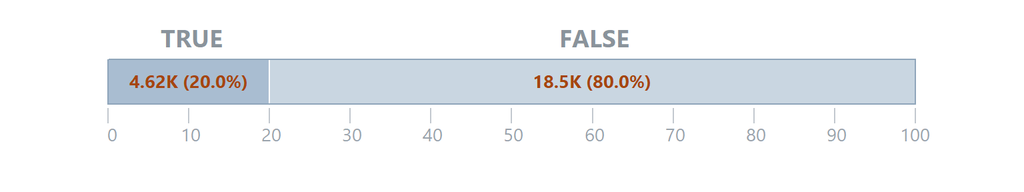

**PREVIEW**:

```
FALSE · TRUE
```

**CATEGORY LABELS**:

| FALSE | TRUE |
| --- | --- |

boolean · indicator

Local capital outlay, excl. utilities (observed flag)

`cog_capital_obs`

Local capital outlay, excl. utilities (F+G). Observed flag: TRUE where the base value was observed that year, FALSE where it was filled. Identical to `cog_curop_obs` in this frame.

| ROWS | DISTINCT |
| --- | --- |
| 23,125 | 2 (0.0%) |

**PREVIEW**:

```
FALSE · TRUE
```

**CATEGORY LABELS**:

| FALSE | TRUE |
| --- | --- |

boolean · indicator

Local assistance and subsidies (observed flag)

`cog_assist_obs`

Local assistance and subsidies (J). Observed flag: TRUE where the base value was observed that year, FALSE where it was filled. Identical to `cog_curop_obs` in this frame.

| ROWS | DISTINCT |
| --- | --- |
| 23,125 | 2 (0.0%) |

**PREVIEW**:

```
FALSE · TRUE
```

**CATEGORY LABELS**:

| FALSE | TRUE |
| --- | --- |

boolean · indicator

Local interest on general debt (observed flag)

`cog_interest_obs`

Local interest on general debt (I89). Observed flag: TRUE where the base value was observed that year, FALSE where it was filled. Identical to `cog_curop_obs` in this frame.

| ROWS | DISTINCT |
| --- | --- |
| 23,125 | 2 (0.0%) |

**PREVIEW**:

```
FALSE · TRUE
```

**CATEGORY LABELS**:

| FALSE | TRUE |
| --- | --- |

boolean · indicator

Local current operations, education (observed flag)

`cog_educ_curop_obs`

Local current operations, education (E12, E16, E18, E21). Observed flag: TRUE where the base value was observed that year, FALSE where it was filled. Identical to `cog_curop_obs` in this frame.

| ROWS | DISTINCT |
| --- | --- |
| 23,125 | 2 (0.0%) |

**PREVIEW**:

```
FALSE · TRUE
```

**CATEGORY LABELS**:

| FALSE | TRUE |
| --- | --- |

boolean · indicator

Local public welfare spending (observed flag)

`cog_welfare_obs`

Local public welfare spending (E/J 67, 68, 74, 75, 77, 79). Observed flag: TRUE where the base value was observed that year, FALSE where it was filled. Identical to `cog_curop_obs` in this frame.

| ROWS | DISTINCT |
| --- | --- |
| 23,125 | 2 (0.0%) |

**PREVIEW**:

```
FALSE · TRUE
```

**CATEGORY LABELS**:

| FALSE | TRUE |
| --- | --- |

boolean · indicator

Local health and hospitals current operations (observed flag)

`cog_health_curop_obs`

Local health and hospitals current operations (E32, E36, E38). Observed flag: TRUE where the base value was observed that year, FALSE where it was filled. Identical to `cog_curop_obs` in this frame.

| ROWS | DISTINCT |
| --- | --- |
| 23,125 | 2 (0.0%) |

**PREVIEW**:

```
FALSE · TRUE
```

**CATEGORY LABELS**:

| FALSE | TRUE |
| --- | --- |

boolean · indicator

Local salaries and wages (observed flag)

`cog_salaries_obs`

Local salaries and wages (Z00; not published for 2022). Observed flag: TRUE where the base value was observed that year, FALSE where it was filled.

| ROWS | DISTINCT |
| --- | --- |
| 23,125 | 2 (0.0%) |

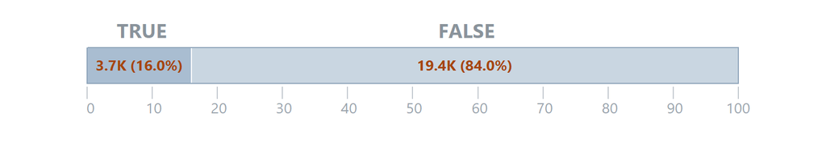

**PREVIEW**:

```
FALSE · TRUE
```

**CATEGORY LABELS**:

| FALSE | TRUE |
| --- | --- |

boolean · indicator

Local intergovernmental revenue from federal government (observed flag)

`cog_fed_igr_obs`

Local intergovernmental revenue from federal government (B). Observed flag: TRUE where the base value was observed that year, FALSE where it was filled. Identical to `cog_curop_obs` in this frame.

| ROWS | DISTINCT |
| --- | --- |
| 23,125 | 2 (0.0%) |

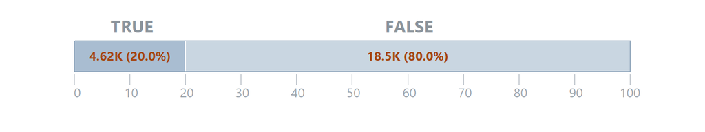

**PREVIEW**:

```
FALSE · TRUE
```

**CATEGORY LABELS**:

| FALSE | TRUE |
| --- | --- |

boolean · indicator

Local intergovernmental revenue from state government (observed flag)

`cog_state_igr_obs`

Local intergovernmental revenue from state government (C). Observed flag: TRUE where the base value was observed that year, FALSE where it was filled. Identical to `cog_curop_obs` in this frame.

| ROWS | DISTINCT |
| --- | --- |
| 23,125 | 2 (0.0%) |

**PREVIEW**:

```
FALSE · TRUE
```

**CATEGORY LABELS**:

| FALSE | TRUE |
| --- | --- |

boolean · indicator

Local direct general expenditure (observed flag)

`cog_dge_obs`

Local direct general expenditure = curop + capital + assist + interest. Observed flag: TRUE where the base value was observed that year, FALSE where it was filled. Identical to `cog_curop_obs` in this frame.

| ROWS | DISTINCT |
| --- | --- |
| 23,125 | 2 (0.0%) |

**PREVIEW**:

```
FALSE · TRUE
```

**CATEGORY LABELS**:

| FALSE | TRUE |
| --- | --- |

boolean · indicator

Personal current transfer receipts (observed flag)

`tr_total_obs`

Personal current transfer receipts. Observed flag: TRUE where the base value was observed that year, FALSE where it was filled.

| ROWS | DISTINCT |
| --- | --- |
| 23,125 | 2 (0.0%) |

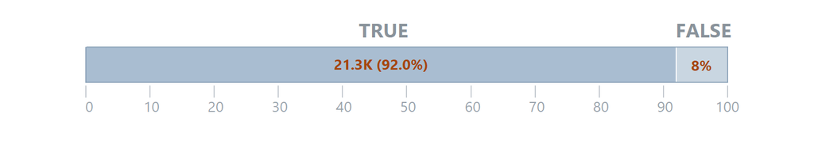

**PREVIEW**:

```
TRUE · FALSE
```

**CATEGORY LABELS**:

| FALSE | TRUE |
| --- | --- |

boolean · indicator

Transfer receipts of individuals from governments (observed flag)

`tr_gov_obs`

Transfer receipts of individuals from governments. Observed flag: TRUE where the base value was observed that year, FALSE where it was filled. Identical to `tr_total_obs` in this frame.

| ROWS | DISTINCT |
| --- | --- |
| 23,125 | 2 (0.0%) |

**PREVIEW**:

```
TRUE · FALSE
```

**CATEGORY LABELS**:

| FALSE | TRUE |
| --- | --- |

boolean · indicator

Social Security benefits (observed flag)

`tr_socsec_obs`

Social Security benefits. Observed flag: TRUE where the base value was observed that year, FALSE where it was filled. Identical to `tr_total_obs` in this frame.

| ROWS | DISTINCT |
| --- | --- |
| 23,125 | 2 (0.0%) |

**PREVIEW**:

```
TRUE · FALSE
```

**CATEGORY LABELS**:

| FALSE | TRUE |
| --- | --- |

boolean · indicator

Medical benefits (observed flag)

`tr_medical_obs`

Medical benefits (Medicare + Medicaid + military). Observed flag: TRUE where the base value was observed that year, FALSE where it was filled. Identical to `tr_total_obs` in this frame.

| ROWS | DISTINCT |
| --- | --- |
| 23,125 | 2 (0.0%) |

**PREVIEW**:

```
TRUE · FALSE
```

**CATEGORY LABELS**:

| FALSE | TRUE |
| --- | --- |

boolean · indicator

Medicare benefits (observed flag)

`tr_medicare_obs`

Medicare benefits. Observed flag: TRUE where the base value was observed that year, FALSE where it was filled. Identical to `tr_total_obs` in this frame.

| ROWS | DISTINCT |
| --- | --- |
| 23,125 | 2 (0.0%) |

**PREVIEW**:

```
TRUE · FALSE
```

**CATEGORY LABELS**:

| FALSE | TRUE |
| --- | --- |

boolean · indicator

Public assistance medical care (observed flag)

`tr_medicaid_obs`

Public assistance medical care (mostly Medicaid). Observed flag: TRUE where the base value was observed that year, FALSE where it was filled. Identical to `tr_total_obs` in this frame.

| ROWS | DISTINCT |
| --- | --- |
| 23,125 | 2 (0.0%) |

**PREVIEW**:

```
TRUE · FALSE
```

**CATEGORY LABELS**:

| FALSE | TRUE |
| --- | --- |

boolean · indicator

Income maintenance (observed flag)

`tr_income_maint_obs`

Income maintenance (SSI, EITC, SNAP, other). Observed flag: TRUE where the base value was observed that year, FALSE where it was filled. Identical to `tr_total_obs` in this frame.

| ROWS | DISTINCT |
| --- | --- |
| 23,125 | 2 (0.0%) |

**PREVIEW**:

```
TRUE · FALSE
```

**CATEGORY LABELS**:

| FALSE | TRUE |
| --- | --- |

boolean · indicator

SNAP benefits (observed flag)

`tr_snap_obs`

SNAP benefits. Observed flag: TRUE where the base value was observed that year, FALSE where it was filled. Identical to `tr_total_obs` in this frame.

| ROWS | DISTINCT |
| --- | --- |
| 23,125 | 2 (0.0%) |

**PREVIEW**:

```
TRUE · FALSE
```

**CATEGORY LABELS**:

| FALSE | TRUE |
| --- | --- |

boolean · indicator

Unemployment insurance compensation (observed flag)

`tr_unemp_obs`

Unemployment insurance compensation. Observed flag: TRUE where the base value was observed that year, FALSE where it was filled. Identical to `tr_total_obs` in this frame.

| ROWS | DISTINCT |
| --- | --- |
| 23,125 | 2 (0.0%) |

**PREVIEW**:

```
TRUE · FALSE
```

**CATEGORY LABELS**:

| FALSE | TRUE |
| --- | --- |

boolean · indicator

Veterans' benefits (observed flag)

`tr_veterans_obs`

Veterans' benefits. Observed flag: TRUE where the base value was observed that year, FALSE where it was filled. Identical to `tr_total_obs` in this frame.

| ROWS | DISTINCT |
| --- | --- |
| 23,125 | 2 (0.0%) |

**PREVIEW**:

```
TRUE · FALSE
```

**CATEGORY LABELS**:

| FALSE | TRUE |
| --- | --- |

boolean · indicator

Education and training assistance (observed flag)

`tr_education_obs`

Education and training assistance. Observed flag: TRUE where the base value was observed that year, FALSE where it was filled. Identical to `tr_total_obs` in this frame.

| ROWS | DISTINCT |
| --- | --- |
| 23,125 | 2 (0.0%) |

**PREVIEW**:

```
TRUE · FALSE
```

**CATEGORY LABELS**:

| FALSE | TRUE |
| --- | --- |

boolean · indicator

Transfer receipts of nonprofit institutions (observed flag)

`tr_nonprofit_obs`

Transfer receipts of nonprofit institutions (descriptive only). Observed flag: TRUE where the base value was observed that year, FALSE where it was filled. Identical to `tr_total_obs` in this frame.

| ROWS | DISTINCT |
| --- | --- |
| 23,125 | 2 (0.0%) |

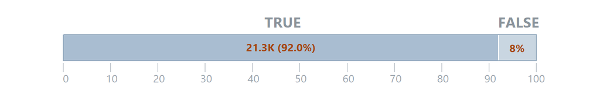

**PREVIEW**:

```
TRUE · FALSE
```

**CATEGORY LABELS**:

| FALSE | TRUE |
| --- | --- |

## Categorical

categorical · unordered

Source of the 990/990-EZ series that year: CORE 2000-10, SOI 2011-1...

`src_990`

Source of the 990/990-EZ series that year: CORE 2000-10, SOI 2011-19, e-file 2020-24

| ROWS | DISTINCT |
| --- | --- |
| 23,125 | 3 (0.0%) |

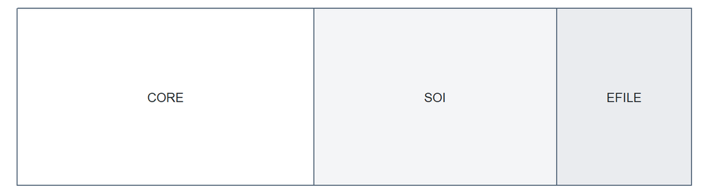

**PREVIEW**:

```
CORE · SOI · EFILE
```

**FACTOR LEVELS**:

| Frequency | (%) | Label |
| --- | --- | --- |
| 10,175 | (44.0%) | CORE |
| 8,325 | (36.0%) | SOI |
| 4,625 | (20.0%) | EFILE |

categorical · unordered

Source of the 990-PF series that year

`src_pf`

Source of the 990-PF series that year

| ROWS | DISTINCT |
| --- | --- |
| 23,125 | 4 (0.0%) |

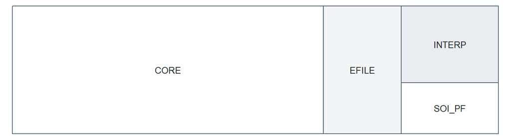

**PREVIEW**:

```
CORE · EFILE · INTERP · SOI_PF
```

**FACTOR LEVELS**:

| Frequency | (%) | Label |
| --- | --- | --- |
| 14,800 | (64.0%) | CORE |
| 3,700 | (16.0%) | EFILE |
| 2,775 | (12.0%) | INTERP |
| 1,850 | (8.0%) | SOI_PF |

categorical · unordered

Metropolitan or micropolitan statistical area

`cbsa_type`

Metropolitan or micropolitan statistical area

| ROWS | DISTINCT |
| --- | --- |
| 23,125 | 2 (0.0%) |

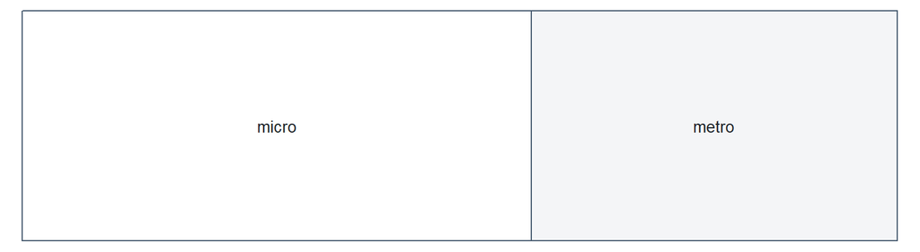

**PREVIEW**:

```
micro · metro
```

**FACTOR LEVELS**:

| Frequency | (%) | Label |
| --- | --- | --- |
| 13,450 | (58.2%) | micro |
| 9,675 | (41.8%) | metro |

## Numeric

number

Resident population, Census PEP July 1

`population`

Resident population, Census PEP July 1

| ROWS | DISTINCT |
| --- | --- |
| 23,125 | 21,739 (94.0%) |

**PREVIEW**:

```
30526 · 36590 · 36814 · 20011 · 20558 · 21763 · 22316 · 22578 · 24593 · 24946 · 25094 · 25263
25482 · 25774 · 25799 · 27128 · 28010 · 29990 · 30702 · 32971 · 33221 · 33468 · 33556 · 33930
```

**STATS**:

| MIN | Q05 | Q25 | Q50 | MEAN | Q75 | Q95 | MAX |
| --- | --- | --- | --- | --- | --- | --- | --- |
| 9,415 | 22,827 | 40,775 | 74,686 | 318,575 | 183,462 | 1,153,534 | 20,080,087 |

number · measurement

Active filers, all 501(c) subsections

`n_filer_all`

Active filers, all 501(c) subsections (max(revenue, expenses) >= $50k in 2010 $)

| ROWS | DISTINCT | ZERO |
| --- | --- | --- |
| 23,125 | 2,207 (9.5%) | 1 (0.0%) |

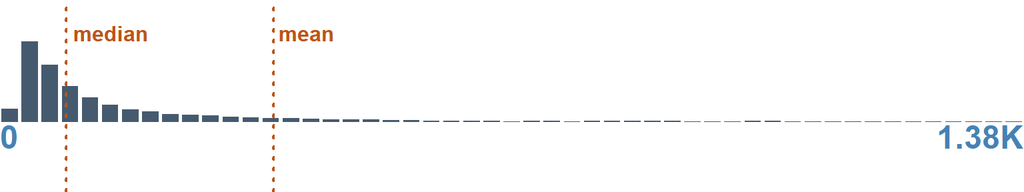

**PREVIEW**:

```
39 · 40 · 36 · 38 · 47 · 45 · 44 · 42 · 51 · 43 · 49 · 28 · 34 · 35 · 41 · 31 · 33 · 30 · 32
46 · 48 · 53 · 37 · 52 · 56 · 50 · 26 · 60 · 55 · 59 · 29 · 54 · 27 · 63 · 65 · 25 · 57 · 71
```

**STATS**:

| MIN | Q05 | Q25 | Q50 | MEAN | Q75 | Q95 | MAX |
| --- | --- | --- | --- | --- | --- | --- | --- |
| 0 | 21 | 46 | 89 | 368.19 | 226 | 1,371.2 | 27,611 |

number

Active 501(c)(3) 990/990-EZ filers

`n_filer_c3`

Active 501(c)(3) 990/990-EZ filers (same floor; 990-PF excluded)

| ROWS | DISTINCT | ZERO |
| --- | --- | --- |
| 23,125 | 1,858 (8.0%) | 4 (0.0%) |

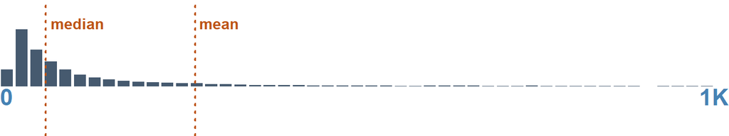

**PREVIEW**:

```
25 · 29 · 30 · 27 · 26 · 33 · 28 · 24 · 23 · 31 · 34 · 38 · 22 · 17 · 21 · 19 · 18 · 32 · 20
36 · 15 · 35 · 39 · 42 · 37 · 40 · 16 · 45 · 13 · 14 · 41 · 43 · 46 · 12 · 50 · 52 · 47 · 54
```

**STATS**:

| MIN | Q05 | Q25 | Q50 | MEAN | Q75 | Q95 | MAX |
| --- | --- | --- | --- | --- | --- | --- | --- |
| 0 | 13 | 31 | 63 | 268.06 | 160 | 994.8 | 22,328 |

number

Active c3 filers excluding hospitals

`n_filer_c3_nohu`

Active c3 filers excluding hospitals (NTEE E20-E24) and universities (B40-B43, B50)

| ROWS | DISTINCT | ZERO |
| --- | --- | --- |
| 23,125 | 1,840 (8.0%) | 4 (0.0%) |

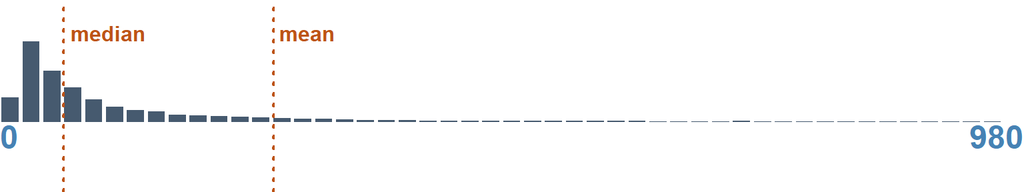

**PREVIEW**:

```
25 · 24 · 30 · 33 · 26 · 27 · 29 · 28 · 21 · 20 · 23 · 22 · 19 · 18 · 34 · 31 · 17 · 32 · 36
37 · 38 · 40 · 15 · 14 · 12 · 13 · 35 · 42 · 16 · 39 · 44 · 45 · 41 · 43 · 50 · 52 · 11 · 51
```

**STATS**:

| MIN | Q05 | Q25 | Q50 | MEAN | Q75 | Q95 | MAX |
| --- | --- | --- | --- | --- | --- | --- | --- |
| 0 | 13 | 30 | 61 | 262.19 | 155 | 973 | 21,985 |

number

Active c3 filers in human services

`n_filer_c3_hs`

Active c3 filers in human services (NTEE major groups I-P)

| ROWS | DISTINCT | ZERO |
| --- | --- | --- |
| 23,125 | 1,111 (4.8%) | 72 (0.3%) |

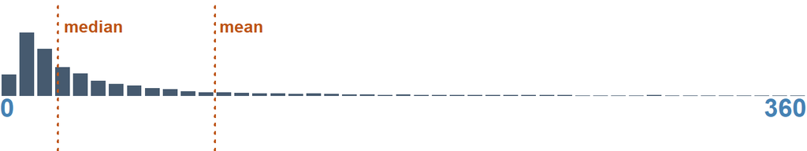

**PREVIEW**:

```
11 · 10 · 7 · 12 · 13 · 14 · 9 · 8 · 6 · 15 · 17 · 16 · 18 · 19 · 5 · 20 · 22 · 4 · 21 · 23 · 28
24 · 25 · 27 · 26 · 32 · 30 · 3 · 31 · 33 · 29 · 35 · 34 · 37 · 38 · 36 · 2 · 42 · 44 · 40 · 39
```

**STATS**:

| MIN | Q05 | Q25 | Q50 | MEAN | Q75 | Q95 | MAX |
| --- | --- | --- | --- | --- | --- | --- | --- |
| 0 | 5 | 13 | 26 | 96.06 | 62 | 359 | 7,012 |

number

All c3 990/990-EZ records, no size floor

`n_filer_c3_nofloor`

All c3 990/990-EZ records, no size floor

| ROWS | DISTINCT | ZERO |
| --- | --- | --- |
| 23,125 | 2,103 (9.1%) | 2 (0.0%) |

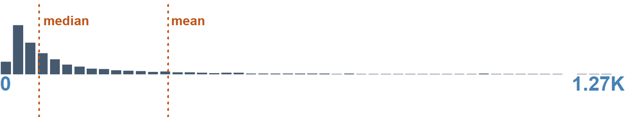

**PREVIEW**:

```
31 · 33 · 35 · 28 · 37 · 32 · 34 · 38 · 29 · 42 · 39 · 40 · 36 · 49 · 44 · 45 · 30 · 43 · 46
23 · 26 · 27 · 25 · 47 · 24 · 41 · 51 · 50 · 52 · 21 · 19 · 20 · 48 · 22 · 53 · 56 · 54 · 64
```

**STATS**:

| MIN | Q05 | Q25 | Q50 | MEAN | Q75 | Q95 | MAX |
| --- | --- | --- | --- | --- | --- | --- | --- |
| 0 | 17 | 40 | 80 | 343.24 | 201 | 1,255.6 | 31,046 |

number · measurement

Total expenses of active filers, all subsections

`exp_all`

Total expenses of active filers, all subsections (2022 $)

| ROWS | DISTINCT | ZERO |
| --- | --- | --- |
| 23,125 | 23,125 (100.0%) | 1 (0.0%) |

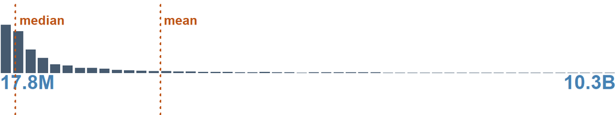

**PREVIEW**:

```
0 · 58396.133 · 81933.923 · 138669.845 · 165090.015 · 166103.163 · 197009.944 · 259868.464
263421.047 · 278582.56 · 380768.506 · 392766.065 · 401270.168 · 409966.25 · 410383.685
```

**STATS**:

| MIN | Q05 | Q25 | Q50 | MEAN | Q75 | Q95 | MAX |
| --- | --- | --- | --- | --- | --- | --- | --- |
| 0 | 17,817,642 | 93,985,639 | 273,419,541 | 2,707,757,841 | 972,329,977 | 10,336,780,347 | 349,323,458,288 |

number · measurement

Total expenses of active c3 filers

`exp_c3`

Total expenses of active c3 filers (2022 $)

| ROWS | DISTINCT | ZERO |
| --- | --- | --- |
| 23,125 | 23,122 (100.0%) | 4 (0.0%) |

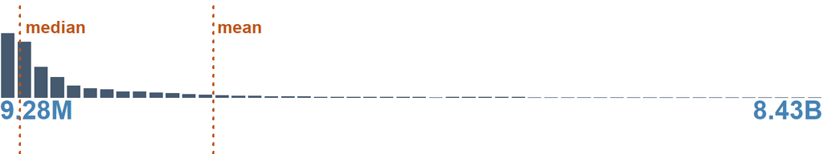

**PREVIEW**:

```
0 · 76850.096 · 99938.475 · 119067.768 · 126493.917 · 130748.556 · 133732.216 · 138669.845
150537.848 · 165090.015 · 166103.163 · 179261.614 · 193446.412 · 201400.247 · 202131.581
```

**STATS**:

| MIN | Q05 | Q25 | Q50 | MEAN | Q75 | Q95 | MAX |
| --- | --- | --- | --- | --- | --- | --- | --- |
| 0 | 9,277,232 | 62,618,352 | 213,344,885 | 2,194,947,053 | 821,683,993 | 8,445,548,321 | 297,033,269,850 |

number · measurement

Total expenses of active c3 filers excluding hospitals and universi...

`exp_c3_nohu`

Total expenses of active c3 filers excluding hospitals and universities (2022 $)

| ROWS | DISTINCT | ZERO |
| --- | --- | --- |
| 23,125 | 23,122 (100.0%) | 4 (0.0%) |

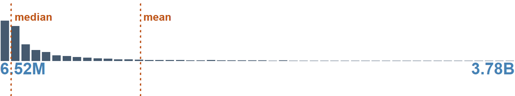

**PREVIEW**:

```
0 · 76850.096 · 99938.475 · 119067.768 · 126493.917 · 130748.556 · 133732.216 · 138669.845
150537.848 · 165090.015 · 166103.163 · 179261.614 · 193446.412 · 201400.247 · 202131.581
```

**STATS**:

| MIN | Q05 | Q25 | Q50 | MEAN | Q75 | Q95 | MAX |
| --- | --- | --- | --- | --- | --- | --- | --- |
| 0 | 6,521,353 | 31,636,565 | 89,224,807 | 1,038,689,131 | 333,590,263 | 3,786,713,866 | 158,720,724,520 |

number · measurement

Total expenses of active human-services c3 filers

`exp_c3_hs`

Total expenses of active human-services c3 filers (2022 $)

| ROWS | DISTINCT | ZERO |
| --- | --- | --- |
| 23,125 | 23,053 (99.7%) | 72 (0.3%) |

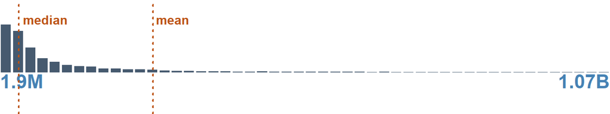

**PREVIEW**:

```
0 · 21187346.644 · 10123.668 · 11245.666 · 16953.062 · 18614.88 · 20588.767 · 42117.37
46101.29 · 50991.049 · 55847.275 · 58333.158 · 60070.223 · 62257.5 · 66175.379 · 66483.979
```

**STATS**:

| MIN | Q05 | Q25 | Q50 | MEAN | Q75 | Q95 | MAX |
| --- | --- | --- | --- | --- | --- | --- | --- |
| 0 | 1,902,986 | 11,208,992 | 34,652,452 | 269,629,784 | 117,841,680 | 1,069,830,121 | 31,068,958,375 |

number · measurement

Total revenue of active c3 filers

`rev_c3`

Total revenue of active c3 filers (2022 $)

| ROWS | DISTINCT | ZERO |
| --- | --- | --- |
| 23,125 | 23,122 (100.0%) | 4 (0.0%) |

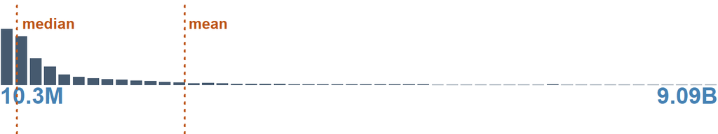

**PREVIEW**:

```
0 · 72437.641 · 77897.732 · 91517.607 · 121817.132 · 127079.496 · 138399.783 · 148959.371
149323.768 · 152718.939 · 159206.21 · 179326.078 · 179551.121 · 189548.391 · 195176.455
```

**STATS**:

| MIN | Q05 | Q25 | Q50 | MEAN | Q75 | Q95 | MAX |
| --- | --- | --- | --- | --- | --- | --- | --- |
| 0 | 10,254,075 | 67,289,891 | 228,955,705 | 2,351,280,566 | 876,252,639 | 9,095,665,042 | 316,123,187,426 |

number · measurement

Total revenue, excluding hospitals and universities

`rev_c3_nohu`

Total revenue, excluding hospitals and universities (2022 $)

| ROWS | DISTINCT | ZERO |
| --- | --- | --- |
| 23,125 | 23,122 (100.0%) | 4 (0.0%) |

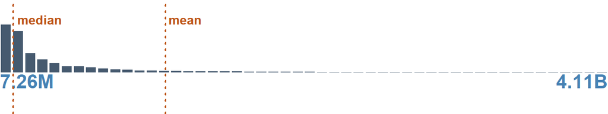

**PREVIEW**:

```
0 · 72437.641 · 77897.732 · 91517.607 · 121817.132 · 127079.496 · 138399.783 · 148959.371
149323.768 · 152718.939 · 159206.21 · 179326.078 · 179551.121 · 189548.391 · 195176.455
```

**STATS**:

| MIN | Q05 | Q25 | Q50 | MEAN | Q75 | Q95 | MAX |
| --- | --- | --- | --- | --- | --- | --- | --- |
| 0 | 7,251,317 | 34,335,324 | 96,671,018 | 1,122,947,513 | 356,776,618 | 4,105,707,841 | 172,000,825,768 |

number · measurement

Grants paid to domestic organizations and governments

`grants_org_c3`

Grants paid to domestic organizations and governments (990 Part IX line 1; 2012+; 2022 $)

| ROWS | DISTINCT | MISSING/NA | ZERO |
| --- | --- | --- | --- |
| 23,125 | 11,701 (50.6%) | 11,100 (48.0%) | 319 (1.4%) |

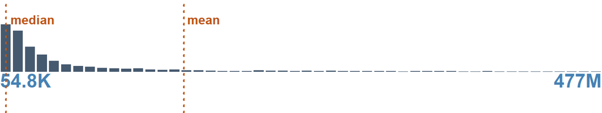

**PREVIEW**:

```
0 · 11925.857 · 580.187 · 750 · 2320.746 · 11210.405 · 118063.069 · 10.903 · 53.377 · 122.193
227.862 · 234.429 · 297.116 · 344.918 · 360.308 · 469.172 · 481.462 · 510.415 · 538.099
```

**STATS**:

| MIN | Q05 | Q25 | Q50 | MEAN | Q75 | Q95 | MAX |
| --- | --- | --- | --- | --- | --- | --- | --- |
| 0 | 54,515.7 | 1,199,205 | 4,981,193 | 145,876,718 | 28,943,427 | 478,809,686 | 20,632,139,555 |

number · measurement

exp_c3 minus grants_org_c3

`exp_c3_net`

exp_c3 minus grants_org_c3 (pass-through removed; 2012+)

| ROWS | DISTINCT | MISSING/NA |
| --- | --- | --- |
| 23,125 | 12,026 (52.0%) | 11,100 (48.0%) |

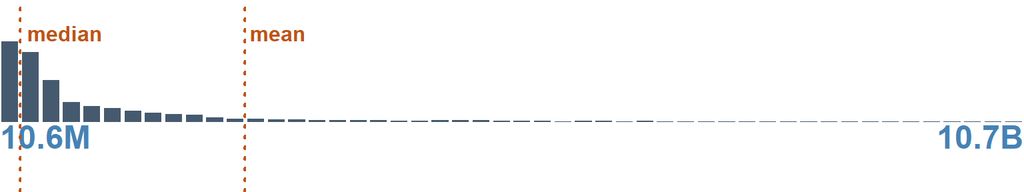

**PREVIEW**:

```
138669.845 · 200042.522 · 213226.755 · 220333.959 · 234436.59 · 236188.658 · 298646.016
304052.121 · 311811.648 · 316599 · 336243.764 · 344107.639 · 372046.579 · 377750.636
```

**STATS**:

| MIN | Q05 | Q25 | Q50 | MEAN | Q75 | Q95 | MAX |
| --- | --- | --- | --- | --- | --- | --- | --- |
| 138,669.8 | 10,594,369 | 62,635,540 | 223,590,550 | 2,567,190,079 | 935,589,284 | 10,711,259,320 | 2.80876e+11 |

number · measurement

exp_c3_nohu minus grants paid

`exp_c3_nohu_net`

exp_c3_nohu minus grants paid (2012+)

| ROWS | DISTINCT | MISSING/NA |
| --- | --- | --- |
| 23,125 | 12,026 (52.0%) | 11,100 (48.0%) |

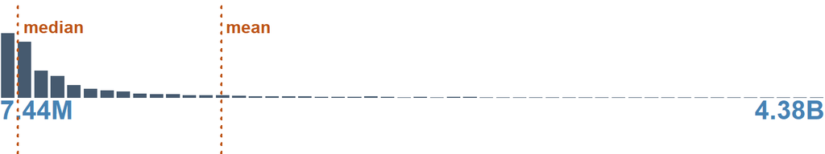

**PREVIEW**:

```
138669.845 · 200042.522 · 213226.755 · 220333.959 · 234436.59 · 236188.658 · 298646.016
304052.121 · 311811.648 · 316599 · 336243.764 · 344107.639 · 372046.579 · 377750.636
```

**STATS**:

| MIN | Q05 | Q25 | Q50 | MEAN | Q75 | Q95 | MAX |
| --- | --- | --- | --- | --- | --- | --- | --- |
| 138,669.8 | 7,439,282 | 35,613,013 | 101,699,700 | 1,182,793,537 | 362,121,301 | 4,394,368,066 | 145,598,345,719 |

number · measurement

rev_c3 minus grants paid

`rev_c3_net`

rev_c3 minus grants paid (2012+)

| ROWS | DISTINCT | MISSING/NA |
| --- | --- | --- |
| 23,125 | 12,026 (52.0%) | 11,100 (48.0%) |

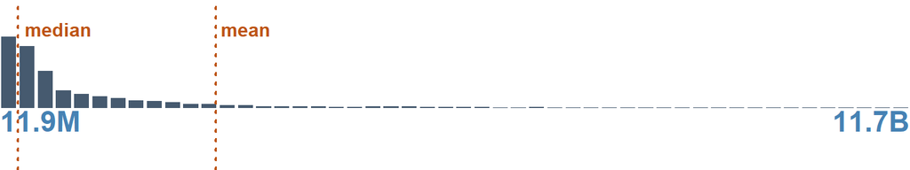

**PREVIEW**:

```
77897.732 · 149323.768 · 189548.391 · 242366.431 · 307134.627 · 331115 · 334405.814 · 339340.921
345235.63 · 362992.76 · 366869 · 376152.479 · 385087.659 · 391012.197 · 494549.806 · 498317.538
```

**STATS**:

| MIN | Q05 | Q25 | Q50 | MEAN | Q75 | Q95 | MAX |
| --- | --- | --- | --- | --- | --- | --- | --- |
| 77,897.73 | 11,873,198 | 69,803,737 | 246,441,657 | 2,777,814,553 | 1,009,494,551 | 11,669,268,762 | 300,297,091,215 |

number · measurement

rev_c3_nohu minus grants paid

`rev_c3_nohu_net`

rev_c3_nohu minus grants paid (2012+)

| ROWS | DISTINCT | MISSING/NA |
| --- | --- | --- |
| 23,125 | 12,026 (52.0%) | 11,100 (48.0%) |

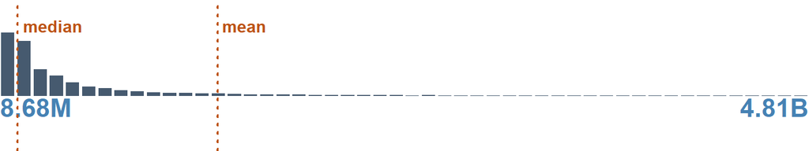

**PREVIEW**:

```
77897.732 · 149323.768 · 189548.391 · 242366.431 · 307134.627 · 331115 · 334405.814 · 339340.921
345235.63 · 362992.76 · 366869 · 376152.479 · 385087.659 · 391012.197 · 494549.806 · 498317.538
```

**STATS**:

| MIN | Q05 | Q25 | Q50 | MEAN | Q75 | Q95 | MAX |
| --- | --- | --- | --- | --- | --- | --- | --- |
| 77,897.73 | 8,656,388 | 39,440,743 | 112,291,824 | 1,302,426,868 | 405,552,495 | 4,819,174,493 | 159,191,324,819 |

number · measurement

Contributions, gifts and grants received by active c3 filers

`con_c3`

Contributions, gifts and grants received by active c3 filers (2022 $)

| ROWS | DISTINCT | ZERO |
| --- | --- | --- |
| 23,125 | 23,120 (100.0%) | 6 (0.0%) |

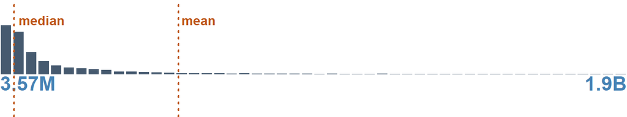

**PREVIEW**:

```
0 · 10094.829 · 12384.046 · 35350.331 · 48109.522 · 51394.836 · 52622.997 · 54557.69 · 59199.731
76161.668 · 77896.769 · 78294.772 · 105258.526 · 107233.977 · 108192.138 · 111244.571
```

**STATS**:

| MIN | Q05 | Q25 | Q50 | MEAN | Q75 | Q95 | MAX |
| --- | --- | --- | --- | --- | --- | --- | --- |
| 0 | 3,565,096 | 16,478,524 | 46,719,399 | 543,266,321 | 167,621,591 | 1,900,312,904 | 85,370,445,193 |

number · measurement

Total assets, end of year, active c3 filers

`assets_c3`

Total assets, end of year, active c3 filers (2022 $)

| ROWS | DISTINCT | ZERO |
| --- | --- | --- |
| 23,125 | 23,122 (100.0%) | 4 (0.0%) |

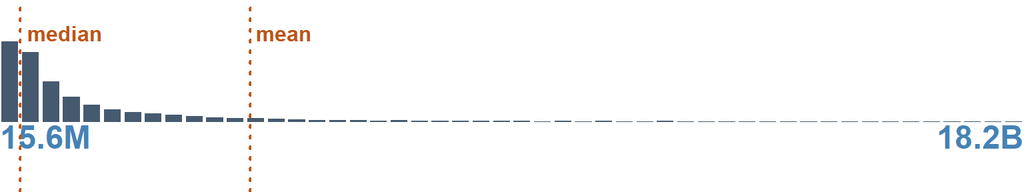

**PREVIEW**:

```
0 · 24683.07 · 47844.946 · 85651.186 · 88180.555 · 88296.2 · 93184.934 · 95977.266 · 107185.213
107990.288 · 110400.578 · 136449.752 · 142499.915 · 180393.563 · 220178.532 · 290260.335
```

**STATS**:

| MIN | Q05 | Q25 | Q50 | MEAN | Q75 | Q95 | MAX |
| --- | --- | --- | --- | --- | --- | --- | --- |
| 0 | 15,625,276 | 106,902,106 | 375,213,096 | 4,464,650,324 | 1,497,915,173 | 18,194,256,366 | 564,494,722,435 |

number

Private foundations filing a 990-PF

`n_pf`

Private foundations filing a 990-PF (no floor)

| ROWS | DISTINCT | ZERO |
| --- | --- | --- |
| 23,125 | 1,163 (5.0%) | 679 (2.9%) |

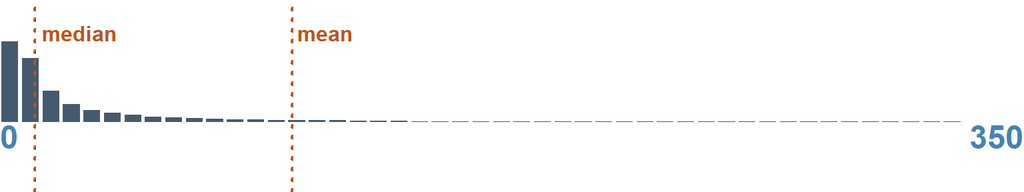

**PREVIEW**:

```
3 · 5 · 4 · 2 · 6 · 7 · 8 · 1 · 9 · 0 · 11 · 12 · 10 · 13 · 14 · 15 · 16 · 17 · 18 · 20 · 19
21 · 22 · 23 · 24 · 26 · 25 · 27 · 32 · 29 · 34 · 28 · 30 · 31 · 33 · 36 · 35 · 37 · 40 · 38
```

**STATS**:

| MIN | Q05 | Q25 | Q50 | MEAN | Q75 | Q95 | MAX |
| --- | --- | --- | --- | --- | --- | --- | --- |
| 0 | 1 | 5 | 12 | 99.84 | 37 | 344 | 12,178 |

number · measurement

Foundation assets, book value end of year

`pf_assets`

Foundation assets, book value end of year (2022 $)

| ROWS | DISTINCT | ZERO |
| --- | --- | --- |
| 23,125 | 22,446 (97.1%) | 661 (2.9%) |

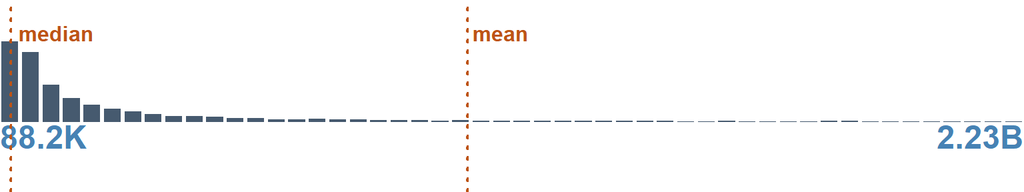

**PREVIEW**:

```
0 · 1.374 · 1.454 · 1.25 · 1.282 · 1.572 · 1.109 · 1.193 · 1.34 · 1.413 · 1.49 · 1.541 · 3.082
1.121 · 1.139 · 1.157 · 1.175 · 1.195 · 1.211 · 1.227 · 1.301
```

**STATS**:

| MIN | Q05 | Q25 | Q50 | MEAN | Q75 | Q95 | MAX |
| --- | --- | --- | --- | --- | --- | --- | --- |
| 0 | 88,104.92 | 5,170,477 | 24,694,240 | 1,017,297,888 | 135,515,774 | 2,231,360,208 | 244,057,773,941 |

number · measurement

Foundation contributions and grants paid

`pf_grants`

Foundation contributions and grants paid (2022 $)

| ROWS | DISTINCT | ZERO |
| --- | --- | --- |
| 23,125 | 21,973 (95.0%) | 1,058 (4.6%) |

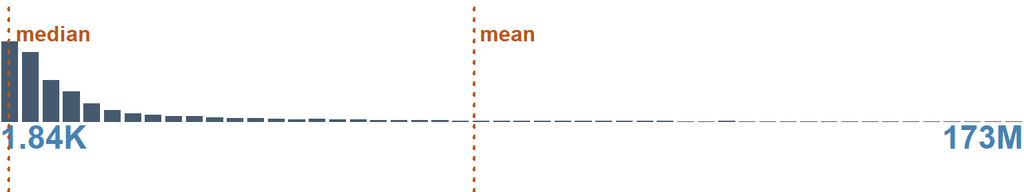

**PREVIEW**:

```
0 · 15409.6 · 1178.889 · 2825.795 · 2979.379 · 3041.968 · 5496.808 · 5814.424 · 5958.758
7502.142 · 8000 · 12167.87 · 28026.012 · 744.845 · 785.926 · 962.925 · 1453.606 · 1540.96
```

**STATS**:

| MIN | Q05 | Q25 | Q50 | MEAN | Q75 | Q95 | MAX |
| --- | --- | --- | --- | --- | --- | --- | --- |
| 0 | 1,828.65 | 281,788.7 | 1,486,258 | 80,246,471 | 8,975,295 | 173,328,895 | 29,863,831,446 |

number · measurement

Registered exempt organizations, all subsections

`n_bmf_all`

Registered exempt organizations, all subsections (reconstructed BMF stock)

| ROWS | DISTINCT |
| --- | --- |
| 23,125 | 4,411 (19.1%) |

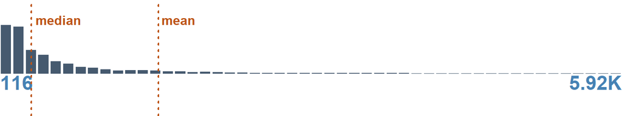

**PREVIEW**:

```
180 · 268 · 255 · 265 · 256 · 257 · 269 · 230 · 233 · 168 · 172 · 239 · 241 · 246 · 262 · 170
253 · 266 · 181 · 182 · 191 · 194 · 244 · 184 · 217 · 224 · 242 · 145 · 193 · 282 · 284 · 160
```

**STATS**:

| MIN | Q05 | Q25 | Q50 | MEAN | Q75 | Q95 | MAX |
| --- | --- | --- | --- | --- | --- | --- | --- |
| 22 | 123 | 231 | 408 | 1,593.78 | 966 | 5,913.4 | 114,571 |

number · measurement

Registered 501(c)(3) organizations

`n_bmf_c3`

Registered 501(c)(3) organizations (reconstructed stock)

| ROWS | DISTINCT |
| --- | --- |
| 23,125 | 3,768 (16.3%) |

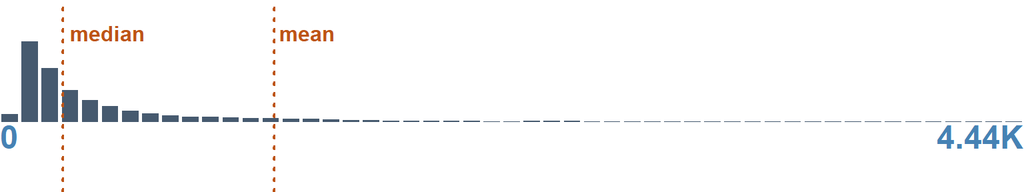

**PREVIEW**:

```
132 · 107 · 117 · 137 · 101 · 121 · 131 · 130 · 139 · 127 · 140 · 152 · 158 · 159 · 104 · 142
143 · 115 · 118 · 126 · 103 · 120 · 134 · 111 · 129 · 136 · 161 · 164 · 155 · 112 · 116 · 128
```

**STATS**:

| MIN | Q05 | Q25 | Q50 | MEAN | Q75 | Q95 | MAX |
| --- | --- | --- | --- | --- | --- | --- | --- |
| 8 | 76 | 148 | 273 | 1,187.91 | 666 | 4,425.4 | 101,065 |

number

Registered 501(c)(3) public charities

`n_bmf_c3pc`

Registered 501(c)(3) public charities (foundation code not 02/03/04)

| ROWS | DISTINCT |
| --- | --- |
| 23,125 | 3,631 (15.7%) |

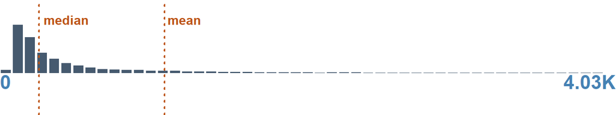

**PREVIEW**:

```
122 · 129 · 114 · 111 · 131 · 94 · 184 · 115 · 132 · 137 · 108 · 136 · 118 · 130 · 107 · 99
119 · 127 · 135 · 97 · 101 · 113 · 124 · 176 · 110 · 155 · 105 · 121 · 134 · 138 · 166 · 190
```

**STATS**:

| MIN | Q05 | Q25 | Q50 | MEAN | Q75 | Q95 | MAX |
| --- | --- | --- | --- | --- | --- | --- | --- |
| 8 | 72 | 140 | 257 | 1,077.06 | 623 | 3,987.4 | 88,486 |

number · measurement

Registered public charities excluding hospitals and universities

`n_bmf_c3pc_nohu`

Registered public charities excluding hospitals and universities

| ROWS | DISTINCT |
| --- | --- |
| 23,125 | 3,618 (15.6%) |

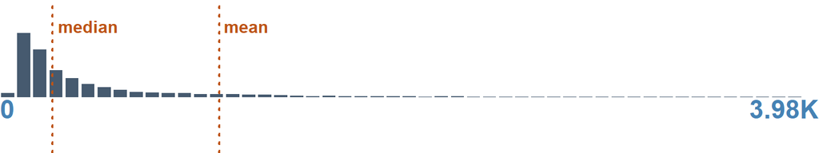

**PREVIEW**:

```
128 · 130 · 121 · 133 · 114 · 147 · 108 · 110 · 118 · 112 · 113 · 126 · 129 · 156 · 135 · 106
92 · 103 · 93 · 116 · 122 · 137 · 186 · 193 · 95 · 98 · 99 · 127 · 94 · 120 · 153 · 101 · 117
```

**STATS**:

| MIN | Q05 | Q25 | Q50 | MEAN | Q75 | Q95 | MAX |
| --- | --- | --- | --- | --- | --- | --- | --- |
| 8 | 71 | 138 | 254 | 1,066.58 | 616 | 3,945.4 | 87,929 |

number

Registered human-services public charities

`n_bmf_c3pc_hs`

Registered human-services public charities (NTEE I-P)

| ROWS | DISTINCT |
| --- | --- |
| 23,125 | 1,936 (8.4%) |

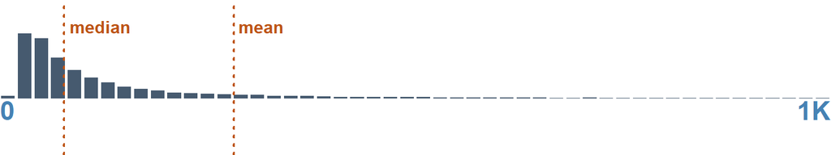

**PREVIEW**:

```
30 · 25 · 31 · 26 · 27 · 33 · 47 · 34 · 29 · 37 · 42 · 49 · 36 · 44 · 45 · 28 · 40 · 52 · 35
32 · 59 · 39 · 43 · 41 · 48 · 38 · 46 · 50 · 55 · 54 · 24 · 51 · 60 · 63 · 23 · 61 · 20 · 56
```

**STATS**:

| MIN | Q05 | Q25 | Q50 | MEAN | Q75 | Q95 | MAX |
| --- | --- | --- | --- | --- | --- | --- | --- |
| 2 | 19 | 42 | 77 | 281.84 | 175 | 1,000.6 | 20,452 |

number

Registered private foundations

`n_bmf_pf`

Registered private foundations

| ROWS | DISTINCT | ZERO |
| --- | --- | --- |
| 23,125 | 1,229 (5.3%) | 328 (1.4%) |

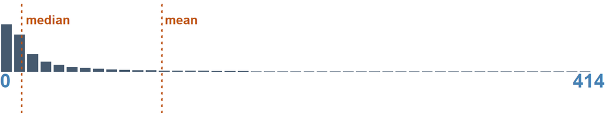

**PREVIEW**:

```
6 · 5 · 7 · 4 · 3 · 8 · 2 · 11 · 9 · 10 · 12 · 13 · 1 · 14 · 16 · 15 · 17 · 21 · 18 · 0 · 19
20 · 23 · 22 · 24 · 25 · 27 · 26 · 28 · 29 · 31 · 34 · 30 · 35 · 32 · 38 · 33 · 36 · 39 · 37
```

**STATS**:

| MIN | Q05 | Q25 | Q50 | MEAN | Q75 | Q95 | MAX |
| --- | --- | --- | --- | --- | --- | --- | --- |
| 0 | 2 | 7 | 15 | 110.86 | 42 | 407 | 14,647 |

number

Raw BMF snapshot count, all subsections

`n_bmf_all_snap`

Raw BMF snapshot count, all subsections (no gap filling)

| ROWS | DISTINCT |
| --- | --- |
| 23,125 | 4,379 (18.9%) |

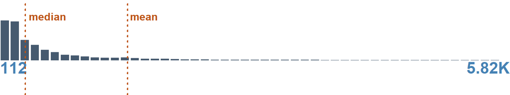

**PREVIEW**:

```
262 · 224 · 178 · 229 · 176 · 190 · 256 · 165 · 231 · 252 · 191 · 235 · 240 · 244 · 146 · 253
257 · 258 · 263 · 265 · 163 · 166 · 167 · 185 · 221 · 248 · 159 · 261 · 266 · 145 · 168 · 216
```

**STATS**:

| MIN | Q05 | Q25 | Q50 | MEAN | Q75 | Q95 | MAX |
| --- | --- | --- | --- | --- | --- | --- | --- |
| 19 | 119 | 224 | 395 | 1,540.22 | 936 | 5,719.6 | 114,496 |

number

Raw snapshot count, 501(c)(3)

`n_bmf_c3_snap`

Raw snapshot count, 501(c)(3)

| ROWS | DISTINCT |
| --- | --- |
| 23,125 | 3,707 (16.0%) |

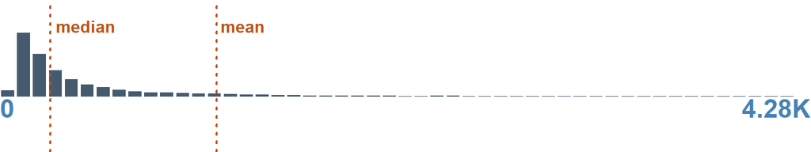

**PREVIEW**:

```
119 · 126 · 134 · 103 · 116 · 131 · 138 · 129 · 114 · 128 · 130 · 124 · 127 · 152 · 149 · 104
109 · 117 · 132 · 156 · 136 · 139 · 96 · 113 · 125 · 133 · 150 · 162 · 142 · 182 · 90 · 111
```

**STATS**:

| MIN | Q05 | Q25 | Q50 | MEAN | Q75 | Q95 | MAX |
| --- | --- | --- | --- | --- | --- | --- | --- |
| 8 | 74 | 143 | 265 | 1,145.39 | 645 | 4,277.2 | 101,065 |

number

Raw snapshot count, c3 public charities

`n_bmf_c3pc_snap`

Raw snapshot count, c3 public charities

| ROWS | DISTINCT |
| --- | --- |
| 23,125 | 3,576 (15.5%) |

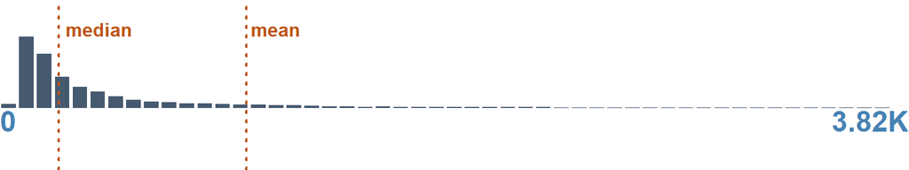

**PREVIEW**:

```
119 · 111 · 112 · 126 · 175 · 87 · 117 · 125 · 128 · 98 · 124 · 131 · 137 · 114 · 132 · 134
156 · 142 · 88 · 115 · 120 · 122 · 148 · 104 · 109 · 127 · 162 · 93 · 100 · 106 · 123 · 147
```

**STATS**:

| MIN | Q05 | Q25 | Q50 | MEAN | Q75 | Q95 | MAX |
| --- | --- | --- | --- | --- | --- | --- | --- |
| 8 | 69 | 136 | 249 | 1,036.97 | 604 | 3,802.4 | 87,254 |

number

`n_bmf_c3pc_nohu_snap`

Raw snapshot count, public charities excluding hospitals and universities

| ROWS | DISTINCT |
| --- | --- |
| 23,125 | 3,551 (15.4%) |

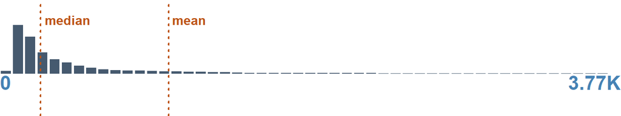

**PREVIEW**:

```
126 · 91 · 95 · 118 · 114 · 116 · 99 · 124 · 125 · 98 · 106 · 147 · 129 · 112 · 123 · 122 · 130
154 · 103 · 119 · 164 · 109 · 127 · 182 · 104 · 105 · 107 · 113 · 117 · 131 · 140 · 155 · 159
```

**STATS**:

| MIN | Q05 | Q25 | Q50 | MEAN | Q75 | Q95 | MAX |
| --- | --- | --- | --- | --- | --- | --- | --- |
| 8 | 68 | 134 | 246 | 1,026.76 | 598 | 3,761.4 | 86,665 |

number

Raw snapshot count, human-services public charities

`n_bmf_c3pc_hs_snap`

Raw snapshot count, human-services public charities

| ROWS | DISTINCT |
| --- | --- |
| 23,125 | 1,867 (8.1%) |

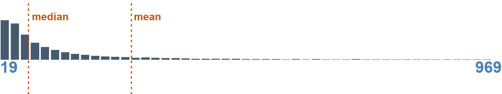

**PREVIEW**:

```
30 · 29 · 25 · 40 · 32 · 46 · 28 · 26 · 37 · 42 · 27 · 36 · 38 · 35 · 34 · 47 · 24 · 33 · 31
44 · 48 · 43 · 45 · 23 · 54 · 41 · 52 · 49 · 22 · 51 · 50 · 56 · 39 · 59 · 55 · 19 · 20 · 21
```

**STATS**:

| MIN | Q05 | Q25 | Q50 | MEAN | Q75 | Q95 | MAX |
| --- | --- | --- | --- | --- | --- | --- | --- |
| 2 | 19 | 40 | 73 | 267.88 | 168 | 952.8 | 20,452 |

number

Raw snapshot count, private foundations

`n_bmf_pf_snap`

Raw snapshot count, private foundations

| ROWS | DISTINCT | ZERO |
| --- | --- | --- |
| 23,125 | 1,206 (5.2%) | 360 (1.6%) |

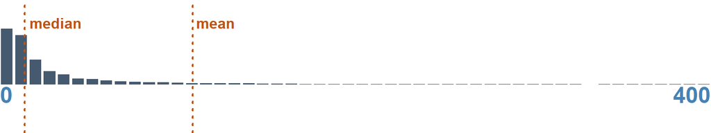

**PREVIEW**:

```
6 · 5 · 4 · 7 · 2 · 3 · 8 · 9 · 10 · 11 · 12 · 1 · 13 · 14 · 15 · 17 · 16 · 0 · 18 · 21 · 20
19 · 23 · 22 · 25 · 24 · 27 · 28 · 26 · 29 · 31 · 32 · 33 · 34 · 30 · 35 · 37 · 36 · 39 · 38
```

**STATS**:

| MIN | Q05 | Q25 | Q50 | MEAN | Q75 | Q95 | MAX |
| --- | --- | --- | --- | --- | --- | --- | --- |
| 0 | 2 | 6 | 14 | 108.42 | 41 | 397 | 14,508 |

number

New 501(c)(3) registrations by ruling year

`n_entry_c3`

New 501(c)(3) registrations by ruling year

| ROWS | DISTINCT | ZERO |
| --- | --- | --- |
| 23,125 | 900 (3.9%) | 307 (1.3%) |

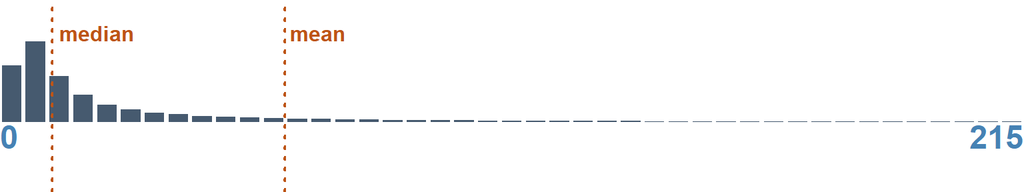

**PREVIEW**:

```
3 · 4 · 5 · 6 · 7 · 2 · 8 · 9 · 10 · 1 · 12 · 11 · 13 · 14 · 16 · 17 · 15 · 18 · 19 · 0 · 22
20 · 23 · 21 · 24 · 26 · 25 · 27 · 28 · 29 · 30 · 33 · 31 · 34 · 35 · 32 · 40 · 37 · 39 · 36
```

**STATS**:

| MIN | Q05 | Q25 | Q50 | MEAN | Q75 | Q95 | MAX |
| --- | --- | --- | --- | --- | --- | --- | --- |
| 0 | 2 | 5 | 11 | 59.8 | 31 | 214 | 5,281 |

number

New public-charity registrations

`n_entry_c3pc`

New public-charity registrations

| ROWS | DISTINCT | ZERO |
| --- | --- | --- |
| 23,125 | 869 (3.8%) | 334 (1.4%) |

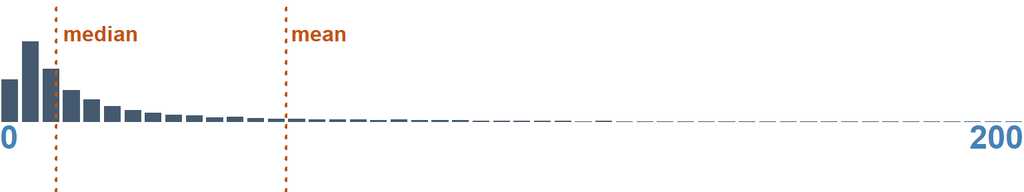

**PREVIEW**:

```
3 · 4 · 5 · 6 · 2 · 7 · 8 · 9 · 1 · 10 · 11 · 12 · 13 · 14 · 16 · 15 · 17 · 0 · 18 · 20 · 19
21 · 22 · 23 · 24 · 26 · 27 · 25 · 29 · 30 · 28 · 31 · 32 · 34 · 33 · 37 · 36 · 40 · 35 · 39
```

**STATS**:

| MIN | Q05 | Q25 | Q50 | MEAN | Q75 | Q95 | MAX |
| --- | --- | --- | --- | --- | --- | --- | --- |
| 0 | 2 | 5 | 11 | 55.89 | 29 | 199 | 4,933 |

number

New public-charity registrations excluding hospitals and universities

`n_entry_c3pc_nohu`

New public-charity registrations excluding hospitals and universities

| ROWS | DISTINCT | ZERO |
| --- | --- | --- |
| 23,125 | 874 (3.8%) | 341 (1.5%) |

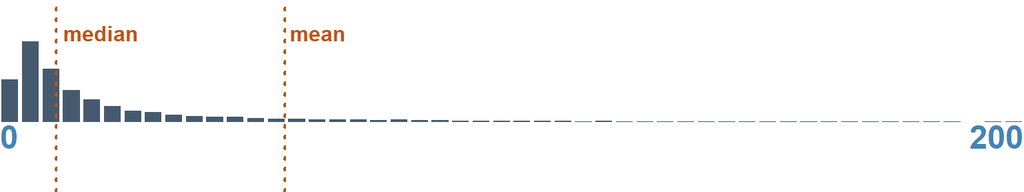

**PREVIEW**:

```
3 · 4 · 5 · 2 · 6 · 7 · 8 · 9 · 1 · 10 · 11 · 12 · 13 · 14 · 16 · 15 · 17 · 0 · 18 · 19 · 20
21 · 22 · 23 · 24 · 26 · 27 · 25 · 29 · 30 · 28 · 31 · 32 · 34 · 33 · 37 · 40 · 36 · 35 · 38
```

**STATS**:

| MIN | Q05 | Q25 | Q50 | MEAN | Q75 | Q95 | MAX |
| --- | --- | --- | --- | --- | --- | --- | --- |
| 0 | 2 | 5 | 11 | 55.6 | 29 | 198 | 4,924 |

number

New private-foundation registrations

`n_entry_pf`

| ROWS | DISTINCT | ZERO |
| --- | --- | --- |
| 23,125 | 210 (0.9%) | 14,366 (62.1%) |

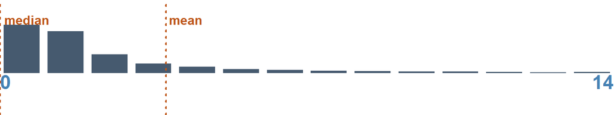

**PREVIEW**:

```
0 · 1 · 2 · 3 · 4 · 5 · 6 · 7 · 8 · 9 · 10 · 11 · 13 · 14 · 12 · 16 · 15 · 19 · 17 · 23 · 18
21 · 22 · 20 · 25 · 24 · 30 · 28 · 26 · 27 · 34 · 29 · 31 · 52 · 36 · 40 · 55 · 35 · 37 · 45
```

**STATS**:

| MIN | Q05 | Q25 | Q50 | MEAN | Q75 | Q95 | MAX |
| --- | --- | --- | --- | --- | --- | --- | --- |
| 0 | 0 | 0 | 0 | 3.79 | 1 | 13 | 871 |

number

Population 25+

`edu_den`

Population 25+

| ROWS | DISTINCT | MISSING/NA |
| --- | --- | --- |
| 23,125 | 13,958 (60.4%) | 8,325 (36.0%) |

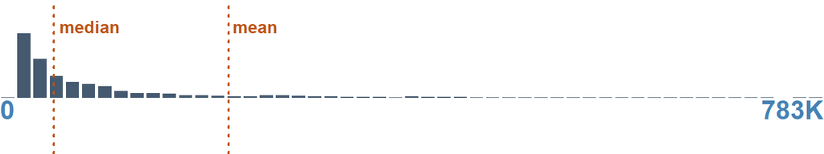

**PREVIEW**:

```
17285 · 24510 · 24865 · 26634 · 26814 · 12544 · 12566 · 14552 · 14974 · 16359 · 17171 · 17336
17516 · 17797 · 18022 · 18326 · 20445 · 21643 · 22196 · 23326 · 23380 · 23675 · 23829 · 24069
```

**STATS**:

| MIN | Q05 | Q25 | Q50 | MEAN | Q75 | Q95 | MAX |
| --- | --- | --- | --- | --- | --- | --- | --- |
| 6,719 | 15,181.85 | 27,099.75 | 51,301 | 217,280.1 | 124,843 | 782,918.4 | 13,970,100 |

number

Population 25+ with BA or higher

`edu_ba_num`

Population 25+ with BA or higher

| ROWS | DISTINCT | MISSING/NA |
| --- | --- | --- |
| 23,125 | 11,916 (51.5%) | 8,325 (36.0%) |

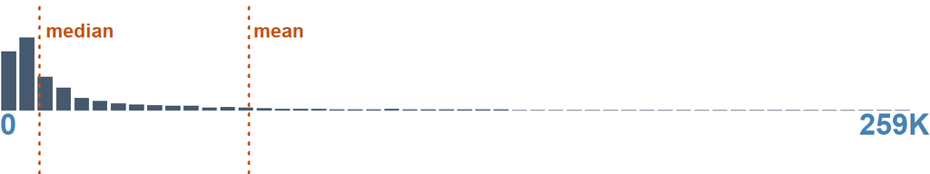

**PREVIEW**:

```
3402 · 4057 · 5619 · 2929 · 3166 · 3361 · 3492 · 3663 · 3673 · 3739 · 3774 · 4186 · 4200 · 4240
4247 · 4281 · 4338 · 4536 · 4975 · 5678 · 5682 · 5683 · 5785 · 6163 · 6661 · 6671 · 7444 · 2343
```

**STATS**:

| MIN | Q05 | Q25 | Q50 | MEAN | Q75 | Q95 | MAX |
| --- | --- | --- | --- | --- | --- | --- | --- |
| 575 | 2,614.95 | 5,185 | 10,975 | 69,303.35 | 33,238.75 | 256,384.6 | 6,168,034 |

number

Foreign-born population

`fb_num`

Foreign-born population

| ROWS | DISTINCT | MISSING/NA |
| --- | --- | --- |
| 23,125 | 9,005 (38.9%) | 8,325 (36.0%) |

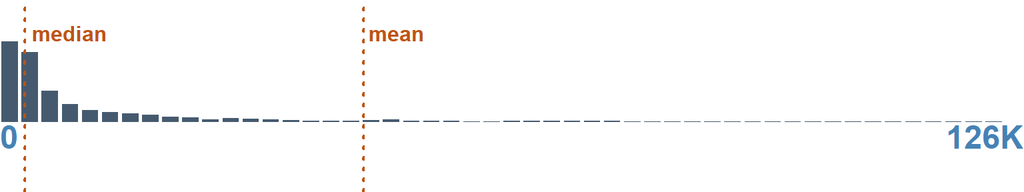

**PREVIEW**:

```
612 · 423 · 430 · 475 · 557 · 568 · 969 · 403 · 435 · 518 · 560 · 633 · 787 · 834 · 1040 · 346
370 · 371 · 397 · 399 · 408 · 420 · 427 · 434 · 437 · 492 · 516 · 528 · 539 · 594 · 610 · 666
```

**STATS**:

| MIN | Q05 | Q25 | Q50 | MEAN | Q75 | Q95 | MAX |
| --- | --- | --- | --- | --- | --- | --- | --- |
| 47 | 393 | 1,205.75 | 3,060.5 | 44,876.06 | 11,495.25 | 124,297.8 | 5,952,555 |

number

Total population

`fb_den`

Total population (place of birth universe)

| ROWS | DISTINCT | MISSING/NA |
| --- | --- | --- |
| 23,125 | 14,199 (61.4%) | 8,325 (36.0%) |

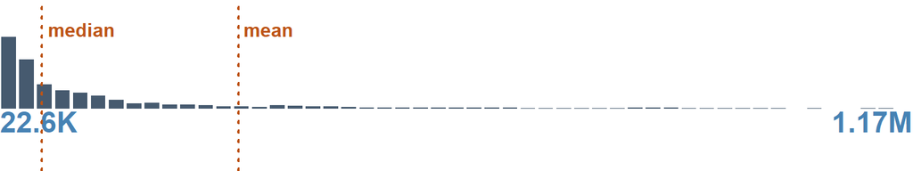

**PREVIEW**:

```
35306 · 20411 · 21839 · 22349 · 25477 · 25584 · 25670 · 28880 · 32055 · 33277 · 34239 · 36323
36503 · 36572 · 36858 · 38084 · 38358 · 39711 · 40641 · 40866 · 41534 · 42150 · 43584 · 44759
```

**STATS**:

| MIN | Q05 | Q25 | Q50 | MEAN | Q75 | Q95 | MAX |
| --- | --- | --- | --- | --- | --- | --- | --- |
| 9,520 | 22,940.85 | 41,010.5 | 75,409 | 323,934.7 | 190,783 | 1,151,994 | 19,953,467 |

number · measurement

Personal income

`personal_income`

Personal income

| ROWS | DISTINCT |
| --- | --- |
| 23,125 | 23,088 (99.8%) |

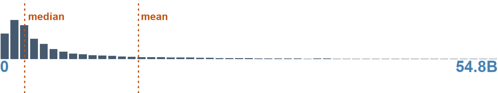

**PREVIEW**:

```
472195000 · 708745000 · 756058000 · 764792000 · 767515000 · 825106000 · 860618000 · 967501000
1011444000 · 1060466000 · 1148796000 · 1184062000 · 1197421000 · 1247055000 · 1248635000
```

**STATS**:

| MIN | Q05 | Q25 | Q50 | MEAN | Q75 | Q95 | MAX |
| --- | --- | --- | --- | --- | --- | --- | --- |
| 160,438,000 | 745,088,600 | 1,396,615,000 | 2,735,424,000 | 15,262,859,889 | 7,372,979,000 | 54,565,364,400 | 1.883565e+12 |

number

Population

`bea_pop`